# Project:the Tmdb_10000_movies_Dataset

# presented by : Ahmed Hamdy Ibrahim Khalil-Egypt

- Introduction
- Data Wrangling
- Exploratory Data Analysis
- Conclusions

# Introduction

In this project I will use a dataset that contains information about 10,000 movies collected from The Movie Database (TMDb),which is considered one of the huge datasets for movies on the internet. this data include data such as the cast,the title, the production company and other information to describe each movie. it also contain the user ratings, revenue, and the budget for each movie. Through this analysis , I will try to answer some interesting questions such as :

**1. What are the top 20 Movies based on the produciton Budget?**

**2. What are the top 20 Movies based on the Revenues ?**

**3. what are the top 20 movies based on the profit ?**

**4. What are the top 20 Movies based on the User Ratings ?**

**5. What are the top 20 movies based on the popularity ?**

**6. What are the top 20 produciton companies ?**

**7. Which genres are most popular over years?**

**8. How much was the production of movies over years?**

```
Finally , I will provide some visualizations to describe the answers
```

```python
#import statements for all of the packages that you plan to use.
import pandas as pd
import numpy as np
import matplotlib.pyplot as plt
import seaborn as sns #not necessary , but make visulaizations look nice.
sns.set_theme()
%matplotlib inline

#matplotlib inline is to make sure the visualizations pop up in jupyter notebooks
# Remember to include a 'magic word' so that your visualizations are plotted
#   inline with the notebook. See this page for more:
#   http://ipython.readthedocs.io/en/stable/interactive/magics.html
```

## Data Wrangling

> In this section of the report, we will start A) load the data, B) assess the data , and C) check for cleanliness.

### General Properties

> **1-Load the Dataset**

```python
# Load your data and print out a few lines.

#load the dataset for tmdb-movies , it's path is (c:/users//python_trial/second_project_investigate_dataset)
tmdb=pd.read_csv("c:/users/Pc/python_trial/second_project_investigate_dataset/tmdb-movies.csv")

#print the first 5 rows of dataset
tmdb.head()
```

|  | id | imdb_id | popularity | budget | revenue | original_title | cast | homepage | director | tagline | ... | overview | runtime | genres | production_companies | release_date | vote_count | vote_average | release_year | budget_adj | revenue_adj |
| --- | --- | --- | --- | --- | --- | --- | --- | --- | --- | --- | --- | --- | --- | --- | --- | --- | --- | --- | --- | --- | --- |
| 0 | 135397 | tt0369610 | 32.985763 | 150000000 | 1513528810 | Jurassic World | Chris Pratt\|Bryce Dallas Howard\|Irrfan Khan\|Vi... | http://www.jurassicworld.com/ | Colin Trevorrow | The park is open. | ... | Twenty-two years after the events of Jurassic ... | 124 | Action\|Adventure\|Science Fiction\|Thriller | Universal Studios\|Amblin Entertainment\|Legenda... | 6/9/15 | 5562 | 6.5 | 2015 | 1.379999e+08 | 1.392446e+09 |
| 1 | 76341 | tt1392190 | 28.419936 | 150000000 | 378436354 | Mad Max: Fury Road | Tom Hardy\|Charlize Theron\|Hugh Keays-Byrne\|Nic... | http://www.madmaxmovie.com/ | George Miller | What a Lovely Day. | ... | An apocalyptic story set in the furthest reach... | 120 | Action\|Adventure\|Science Fiction\|Thriller | Village Roadshow Pictures\|Kennedy Miller Produ... | 5/13/15 | 6185 | 7.1 | 2015 | 1.379999e+08 | 3.481613e+08 |
| 2 | 262500 | tt2908446 | 13.112507 | 110000000 | 295238201 | Insurgent | Shailene Woodley\|Theo James\|Kate Winslet\|Ansel... | http://www.thedivergentseries.movie/#insurgent | Robert Schwentke | One Choice Can Destroy You | ... | Beatrice Prior must confront her inner demons ... | 119 | Adventure\|Science Fiction\|Thriller | Summit Entertainment\|Mandeville Films\|Red Wago... | 3/18/15 | 2480 | 6.3 | 2015 | 1.012000e+08 | 2.716190e+08 |
| 3 | 140607 | tt2488496 | 11.173104 | 200000000 | 2068178225 | Star Wars: The Force Awakens | Harrison Ford\|Mark Hamill\|Carrie Fisher\|Adam D... | http://www.starwars.com/films/star-wars-episod... | J.J. Abrams | Every generation has a story. | ... | Thirty years after defeating the Galactic Empi... | 136 | Action\|Adventure\|Science Fiction\|Fantasy | Lucasfilm\|Truenorth Productions\|Bad Robot | 12/15/15 | 5292 | 7.5 | 2015 | 1.839999e+08 | 1.902723e+09 |
| 4 | 168259 | tt2820852 | 9.335014 | 190000000 | 1506249360 | Furious 7 | Vin Diesel\|Paul Walker\|Jason Statham\|Michelle ... | http://www.furious7.com/ | James Wan | Vengeance Hits Home | ... | Deckard Shaw seeks revenge against Dominic Tor... | 137 | Action\|Crime\|Thriller | Universal Pictures\|Original Film\|Media Rights ... | 4/1/15 | 2947 | 7.3 | 2015 | 1.747999e+08 | 1.385749e+09 |

5 rows × 21 columns

```python
#print the last 5 rows od the dataset:
tmdb.tail()
```

|  | id | imdb_id | popularity | budget | revenue | original_title | cast | homepage | director | tagline | ... | overview | runtime | genres | production_companies | release_date | vote_count | vote_average | release_year | budget_adj | revenue_adj |
| --- | --- | --- | --- | --- | --- | --- | --- | --- | --- | --- | --- | --- | --- | --- | --- | --- | --- | --- | --- | --- | --- |
| 10861 | 21 | tt0060371 | 0.080598 | 0 | 0 | The Endless Summer | Michael Hynson\|Robert August\|Lord 'Tally Ho' B... | NaN | Bruce Brown | NaN | ... | The Endless Summer, by Bruce Brown, is one of ... | 95 | Documentary | Bruce Brown Films | 6/15/66 | 11 | 7.4 | 1966 | 0.000000 | 0.0 |
| 10862 | 20379 | tt0060472 | 0.065543 | 0 | 0 | Grand Prix | James Garner\|Eva Marie Saint\|Yves Montand\|Tosh... | NaN | John Frankenheimer | Cinerama sweeps YOU into a drama of speed and ... | ... | Grand Prix driver Pete Aron is fired by his te... | 176 | Action\|Adventure\|Drama | Cherokee Productions\|Joel Productions\|Douglas ... | 12/21/66 | 20 | 5.7 | 1966 | 0.000000 | 0.0 |
| 10863 | 39768 | tt0060161 | 0.065141 | 0 | 0 | Beregis Avtomobilya | Innokentiy Smoktunovskiy\|Oleg Efremov\|Georgi Z... | NaN | Eldar Ryazanov | NaN | ... | An insurance agent who moonlights as a carthie... | 94 | Mystery\|Comedy | Mosfilm | 1/1/66 | 11 | 6.5 | 1966 | 0.000000 | 0.0 |
| 10864 | 21449 | tt0061177 | 0.064317 | 0 | 0 | What's Up, Tiger Lily? | Tatsuya Mihashi\|Akiko Wakabayashi\|Mie Hama\|Joh... | NaN | Woody Allen | WOODY ALLEN STRIKES BACK! | ... | In comic Woody Allen's film debut, he took the... | 80 | Action\|Comedy | Benedict Pictures Corp. | 11/2/66 | 22 | 5.4 | 1966 | 0.000000 | 0.0 |
| 10865 | 22293 | tt0060666 | 0.035919 | 19000 | 0 | Manos: The Hands of Fate | Harold P. Warren\|Tom Neyman\|John Reynolds\|Dian... | NaN | Harold P. Warren | It's Shocking! It's Beyond Your Imagination! | ... | A family gets lost on the road and stumbles up... | 74 | Horror | Norm-Iris | 11/15/66 | 15 | 1.5 | 1966 | 127642.279154 | 0.0 |

5 rows × 21 columns

```python
#fequantily check for the dataset
tmdb.describe()
```

|  | id | popularity | budget | revenue | runtime | vote_count | vote_average | release_year | budget_adj | revenue_adj |
| --- | --- | --- | --- | --- | --- | --- | --- | --- | --- | --- |
| count | 10866.000000 | 10866.000000 | 1.086600e+04 | 1.086600e+04 | 10866.000000 | 10866.000000 | 10866.000000 | 10866.000000 | 1.086600e+04 | 1.086600e+04 |
| mean | 66064.177434 | 0.646441 | 1.462570e+07 | 3.982332e+07 | 102.070863 | 217.389748 | 5.974922 | 2001.322658 | 1.755104e+07 | 5.136436e+07 |
| std | 92130.136561 | 1.000185 | 3.091321e+07 | 1.170035e+08 | 31.381405 | 575.619058 | 0.935142 | 12.812941 | 3.430616e+07 | 1.446325e+08 |
| min | 5.000000 | 0.000065 | 0.000000e+00 | 0.000000e+00 | 0.000000 | 10.000000 | 1.500000 | 1960.000000 | 0.000000e+00 | 0.000000e+00 |
| 25% | 10596.250000 | 0.207583 | 0.000000e+00 | 0.000000e+00 | 90.000000 | 17.000000 | 5.400000 | 1995.000000 | 0.000000e+00 | 0.000000e+00 |
| 50% | 20669.000000 | 0.383856 | 0.000000e+00 | 0.000000e+00 | 99.000000 | 38.000000 | 6.000000 | 2006.000000 | 0.000000e+00 | 0.000000e+00 |
| 75% | 75610.000000 | 0.713817 | 1.500000e+07 | 2.400000e+07 | 111.000000 | 145.750000 | 6.600000 | 2011.000000 | 2.085325e+07 | 3.369710e+07 |
| max | 417859.000000 | 32.985763 | 4.250000e+08 | 2.781506e+09 | 900.000000 | 9767.000000 | 9.200000 | 2015.000000 | 4.250000e+08 | 2.827124e+09 |

```python
#get info about colums od dataset
tmdb.info()
```

```
<class 'pandas.core.frame.DataFrame'>
RangeIndex: 10866 entries, 0 to 10865
Data columns (total 21 columns):
 #   Column                Non-Null Count  Dtype
---  ------                --------------  -----
 0   id                    10866 non-null  int64
 1   imdb_id               10856 non-null  object
 2   popularity            10866 non-null  float64
 3   budget                10866 non-null  int64
 4   revenue               10866 non-null  int64
 5   original_title        10866 non-null  object
 6   cast                  10790 non-null  object
 7   homepage              2936 non-null   object
 8   director              10822 non-null  object
 9   tagline               8042 non-null   object
 10  keywords              9373 non-null   object
 11  overview              10862 non-null  object
 12  runtime               10866 non-null  int64
 13  genres                10843 non-null  object
 14  production_companies  9836 non-null   object
 15  release_date          10866 non-null  object
 16  vote_count            10866 non-null  int64
 17  vote_average          10866 non-null  float64
 18  release_year          10866 non-null  int64
 19  budget_adj            10866 non-null  float64
 20  revenue_adj           10866 non-null  float64
dtypes: float64(4), int64(6), object(11)
memory usage: 1.7+ MB
```

> **2-Describe the Dataset:**

**1-** The Dataset includes :

```
      1) Total Number of original Columns = 21 columns  -before cleaning-

      2) Total Number of original Rows    = 10866  rows  -before cleaning-
```

**2-** Ther are columns with Null Values , they are **['cast','homepage','director','tagline','overview','genres','production_copmanies']**.

**3-** The dataset have many movies where the budget or revenue have a value of '0'.

**4-** Their is only one duplicated data record.

### Cleaning Data

From this Information about the dataset ,and the questions we hope to answer , We have issues need to be solved:

1) Not rquired columns.

2) The Null & duplicated Values.

3) The Zeros values.

4) Change datatype for ['release_date'].

we will go through three steps to deal with missing data as following ,

> **1- Not required columns:**

```python
#remove not required columns, and mpdify to the original Dataset:
tmdb.drop(['imdb_id','cast','homepage','tagline','keywords','overview'],axis=1,inplace=True)
```

```python
#check for drop success
tmdb.head()
```

|  | id | popularity | budget | revenue | original_title | director | runtime | genres | production_companies | release_date | vote_count | vote_average | release_year | budget_adj | revenue_adj |
| --- | --- | --- | --- | --- | --- | --- | --- | --- | --- | --- | --- | --- | --- | --- | --- |
| 0 | 135397 | 32.985763 | 150000000 | 1513528810 | Jurassic World | Colin Trevorrow | 124 | Action\|Adventure\|Science Fiction\|Thriller | Universal Studios\|Amblin Entertainment\|Legenda... | 6/9/15 | 5562 | 6.5 | 2015 | 1.379999e+08 | 1.392446e+09 |
| 1 | 76341 | 28.419936 | 150000000 | 378436354 | Mad Max: Fury Road | George Miller | 120 | Action\|Adventure\|Science Fiction\|Thriller | Village Roadshow Pictures\|Kennedy Miller Produ... | 5/13/15 | 6185 | 7.1 | 2015 | 1.379999e+08 | 3.481613e+08 |
| 2 | 262500 | 13.112507 | 110000000 | 295238201 | Insurgent | Robert Schwentke | 119 | Adventure\|Science Fiction\|Thriller | Summit Entertainment\|Mandeville Films\|Red Wago... | 3/18/15 | 2480 | 6.3 | 2015 | 1.012000e+08 | 2.716190e+08 |
| 3 | 140607 | 11.173104 | 200000000 | 2068178225 | Star Wars: The Force Awakens | J.J. Abrams | 136 | Action\|Adventure\|Science Fiction\|Fantasy | Lucasfilm\|Truenorth Productions\|Bad Robot | 12/15/15 | 5292 | 7.5 | 2015 | 1.839999e+08 | 1.902723e+09 |
| 4 | 168259 | 9.335014 | 190000000 | 1506249360 | Furious 7 | James Wan | 137 | Action\|Crime\|Thriller | Universal Pictures\|Original Film\|Media Rights ... | 4/1/15 | 2947 | 7.3 | 2015 | 1.747999e+08 | 1.385749e+09 |

```python
#check for info
tmdb.info()
```

```
<class 'pandas.core.frame.DataFrame'>
RangeIndex: 10866 entries, 0 to 10865
Data columns (total 15 columns):
 #   Column                Non-Null Count  Dtype
---  ------                --------------  -----
 0   id                    10866 non-null  int64
 1   popularity            10866 non-null  float64
 2   budget                10866 non-null  int64
 3   revenue               10866 non-null  int64
 4   original_title        10866 non-null  object
 5   director              10822 non-null  object
 6   runtime               10866 non-null  int64
 7   genres                10843 non-null  object
 8   production_companies  9836 non-null   object
 9   release_date          10866 non-null  object
 10  vote_count            10866 non-null  int64
 11  vote_average          10866 non-null  float64
 12  release_year          10866 non-null  int64
 13  budget_adj            10866 non-null  float64
 14  revenue_adj           10866 non-null  float64
dtypes: float64(4), int64(6), object(5)
memory usage: 1.2+ MB
```

> **2-The Null Values :**

check remaining columns with null data , and figure out how to fillin or drop , based on each sitaution. We still have have Column with Null data they are :

```
              [production_companies] have 1030 Null Data.
              [director]             have 44 Null Data.
              [genres]               have 23 Null Data.
```

We need to check how to fill them , as we will use them for our staticistices,

I will go with drop all those Null data from out Dataset.

```python
#remove all Null data , and save them to the orignial dataset
tmdb.dropna(inplace = True)
```

```python
#there is anotehr solution to remove null data from the three columns
#I will begin with the ['production_companies'] then ['director']then['genres'], since it has the greatest number of Null data
#tmdb = tmdb[tmdb['production_companies'].isnull()==False]
#tmdb = tmdb[tmdb['director'].isnull()==False]
#tmdb = tmdb[tmdb['genres'].isnull()==False]
```

```python
#check for success of Null Data remove
tmdb.isnull().sum()
```

```
id                      0
popularity              0
budget                  0
revenue                 0
original_title          0
director                0
runtime                 0
genres                  0
production_companies    0
release_date            0
vote_count              0
vote_average            0
release_year            0
budget_adj              0
revenue_adj             0
dtype: int64
```

```python
#check for the number of rows and columns after removing Null Values
tmdb.shape
```

```
(9807, 15)
```

> **3-The Zero & duplicate Values :**

This dataset has only **1 duplicate Value** , and we will drop it from the dataset.

for **zeros Values** columns of ['budget','revenue'] , have zero values, easy way is to remove them desbite their number.

```python
#we have only one duplicate in the dataset , we will remove it
tmdb.drop_duplicates(inplace=True)
```

```python
#removing the zero values from the dataset
tmdb = tmdb[tmdb.budget != 0 ]
tmdb = tmdb [tmdb.revenue != 0]
```

```python
#final describtion of the data after cleaning for Null, zeros,andnot required columns
tmdb.describe()
```

|  | id | popularity | budget | revenue | runtime | vote_count | vote_average | release_year | budget_adj | revenue_adj |
| --- | --- | --- | --- | --- | --- | --- | --- | --- | --- | --- |
| count | 3807.000000 | 3807.000000 | 3.807000e+03 | 3.807000e+03 | 3807.000000 | 3807.000000 | 3807.000000 | 3807.000000 | 3.807000e+03 | 3.807000e+03 |
| mean | 40031.108484 | 1.203220 | 3.758903e+07 | 1.089161e+08 | 109.350932 | 533.886787 | 6.170239 | 2001.230890 | 4.469723e+07 | 1.386431e+08 |
| std | 67569.158096 | 1.480385 | 4.231877e+07 | 1.772686e+08 | 19.845761 | 883.605159 | 0.792423 | 11.327031 | 4.488596e+07 | 2.169636e+08 |
| min | 5.000000 | 0.010335 | 1.000000e+00 | 2.000000e+00 | 15.000000 | 10.000000 | 2.200000 | 1960.000000 | 9.693980e-01 | 2.370705e+00 |
| 25% | 5940.000000 | 0.470439 | 1.000000e+07 | 1.425795e+07 | 96.000000 | 74.000000 | 5.700000 | 1995.000000 | 1.354637e+07 | 1.919970e+07 |
| 50% | 11257.000000 | 0.809646 | 2.500000e+07 | 4.620143e+07 | 106.000000 | 208.000000 | 6.200000 | 2004.000000 | 3.038360e+07 | 6.282247e+07 |
| 75% | 38577.000000 | 1.386953 | 5.000000e+07 | 1.260554e+08 | 119.000000 | 584.000000 | 6.700000 | 2010.000000 | 6.082825e+07 | 1.656493e+08 |
| max | 417859.000000 | 32.985763 | 4.250000e+08 | 2.781506e+09 | 338.000000 | 9767.000000 | 8.400000 | 2015.000000 | 4.250000e+08 | 2.827124e+09 |

```python
#check for the number of rows and columns after removing duplicated Values
tmdb.shape
```

```
(3807, 15)
```

> **4-The Date Time for ['release_date']:**

```python
#convert the column to dateframes
tmdb['release_date_time '] = pd.to_datetime(tmdb['release_date'])
#I will try to use this convert , to count the highest day to release movies in it#
#check for success
tmdb.info()
```

```
<class 'pandas.core.frame.DataFrame'>
Int64Index: 3807 entries, 0 to 10848
Data columns (total 16 columns):
 #   Column                Non-Null Count  Dtype
---  ------                --------------  -----
 0   id                    3807 non-null   int64
 1   popularity            3807 non-null   float64
 2   budget                3807 non-null   int64
 3   revenue               3807 non-null   int64
 4   original_title        3807 non-null   object
 5   director              3807 non-null   object
 6   runtime               3807 non-null   int64
 7   genres                3807 non-null   object
 8   production_companies  3807 non-null   object
 9   release_date          3807 non-null   object
 10  vote_count            3807 non-null   int64
 11  vote_average          3807 non-null   float64
 12  release_year          3807 non-null   int64
 13  budget_adj            3807 non-null   float64
 14  revenue_adj           3807 non-null   float64
 15  release_date_time     3807 non-null   datetime64[ns]
dtypes: datetime64[ns](1), float64(4), int64(6), object(5)
memory usage: 505.6+ KB
```

```python
#again check the shape of the final data
tmdb.shape
```

```
(3807, 16)
```

### Final Data to analysis

[output not shown]

```python
tmdb.head()
```

|  | id | popularity | budget | revenue | original_title | director | runtime | genres | production_companies | release_date | vote_count | vote_average | release_year | budget_adj | revenue_adj | release_date_time |
| --- | --- | --- | --- | --- | --- | --- | --- | --- | --- | --- | --- | --- | --- | --- | --- | --- |
| 0 | 135397 | 32.985763 | 150000000 | 1513528810 | Jurassic World | Colin Trevorrow | 124 | Action\|Adventure\|Science Fiction\|Thriller | Universal Studios\|Amblin Entertainment\|Legenda... | 6/9/15 | 5562 | 6.5 | 2015 | 1.379999e+08 | 1.392446e+09 | 2015-06-09 |
| 1 | 76341 | 28.419936 | 150000000 | 378436354 | Mad Max: Fury Road | George Miller | 120 | Action\|Adventure\|Science Fiction\|Thriller | Village Roadshow Pictures\|Kennedy Miller Produ... | 5/13/15 | 6185 | 7.1 | 2015 | 1.379999e+08 | 3.481613e+08 | 2015-05-13 |
| 2 | 262500 | 13.112507 | 110000000 | 295238201 | Insurgent | Robert Schwentke | 119 | Adventure\|Science Fiction\|Thriller | Summit Entertainment\|Mandeville Films\|Red Wago... | 3/18/15 | 2480 | 6.3 | 2015 | 1.012000e+08 | 2.716190e+08 | 2015-03-18 |
| 3 | 140607 | 11.173104 | 200000000 | 2068178225 | Star Wars: The Force Awakens | J.J. Abrams | 136 | Action\|Adventure\|Science Fiction\|Fantasy | Lucasfilm\|Truenorth Productions\|Bad Robot | 12/15/15 | 5292 | 7.5 | 2015 | 1.839999e+08 | 1.902723e+09 | 2015-12-15 |
| 4 | 168259 | 9.335014 | 190000000 | 1506249360 | Furious 7 | James Wan | 137 | Action\|Crime\|Thriller | Universal Pictures\|Original Film\|Media Rights ... | 4/1/15 | 2947 | 7.3 | 2015 | 1.747999e+08 | 1.385749e+09 | 2015-04-01 |

## Exploratory Data Analysis

> **Tip**: Now that you've trimmed and cleaned your data, you're ready to move on to exploration. Compute statistics and create visualizations with the goal of addressing the research questions that you posed in the Introduction section. It is recommended that you be systematic with your approach. Look at one variable at a time, and then follow it up by looking at relationships between variables.

### Research Question 1 (what are the top 20 movies based on the production budget? )

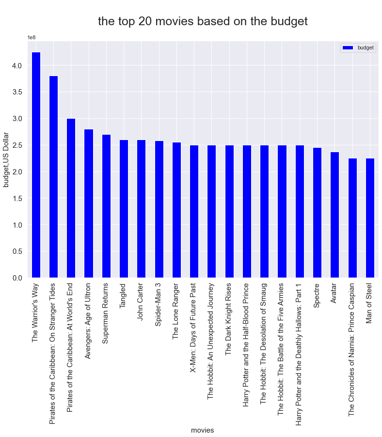

```python
# Udacity: Use this, and more code cells, to explore your data. Don't forget to add
#   Markdown cells to document your observations and findings.

#this will be based on their production budget
#calculate the top 20 movies based on their  budget
movies_with_budgets = tmdb[['original_title','budget']]

#sort the column of budget_adj in Descnding order
movies_with_budgets = movies_with_budgets.sort_values(by = 'budget',ascending = False).head(20)

#plot the data
movies_with_budgets.plot(x = 'original_title', y = 'budget', kind = 'bar',color='blue',figsize = (13,9),fontsize=15);
plt.title(' \nthe top 20 movies based on the budget\n',fontsize = 25)
plt.xlabel("movies", fontsize=15)
plt.ylabel("budget,US Dollar", fontsize=15)
plt.grid(True)
plt.savefig('top 20 movies on budget.jpg')
plt.show();
```

According the shown Figure , The Top of the Top 20 movies in the production budget is **The Warrior's Way** with budget of **425,000,000.0** US Dollar , that movie was produced by **Boram Entertainment inc.** and directed by **Sngmoo Lee**.

### Research Question 2 (what are the top 20 movies based on the revenue? )

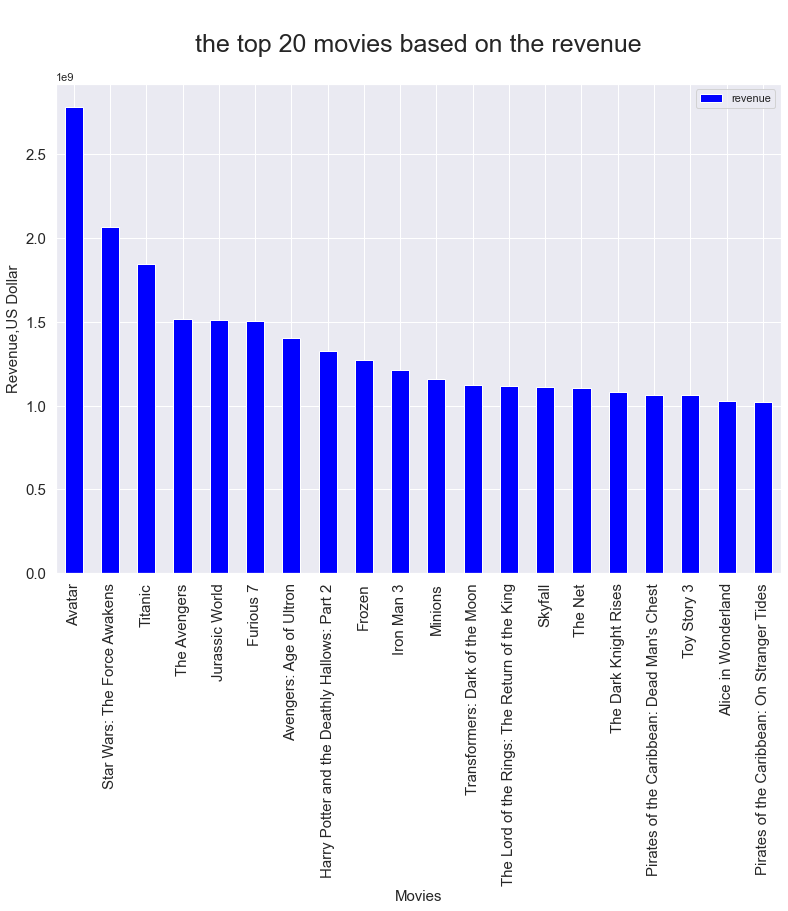

```python
#calculation will be on on their revenue

#calculate the top 20 movies base on their revenues
movies_with_revenue = tmdb[['original_title','revenue']]

#sort the column of budget in Descnding order
movies_with_revenue = movies_with_revenue.sort_values(by = 'revenue',ascending = False).head(20)

#plot the data
movies_with_revenue.plot(x = 'original_title', y = 'revenue', kind = 'bar',color='blue',figsize = (13,9),fontsize=15);
plt.title(' \nthe top 20 movies based on the revenue\n',fontsize = 25)
plt.xlabel("Movies", fontsize=15)
plt.ylabel("Revenue,US Dollar", fontsize=15)
plt.grid(True)
plt.savefig('top 20 movies on revenue.jpg');
```

According to the shown Figure about the top 20 movies based on their revenue , The Top of those movies is **Avater** which was release on **2009**. produced by **Ingenious Film Partners|Twentieth Century Fox** and it's revenues was more than **2,781,000,000** US Dollars . this movie was directed by **James Cameron**.

While the last movie in those top 20 of the highest revenues is **Pirates of the Caribbean: On Stranger Tides** , that was released on **2011** , produced by **Walt Desiney Pictures and other parteners** with total Revenue of **1,021,683,000** US Dollar ,that movie was directed by **Joss Whedon**.

### Research Question 3 (what are the top 20 movies based on the Net Profit?)

this question can be answered through calcualting the Profit Value for each Movie in the dataset

**Profit** = **Revenue** - **Budget**

there for , we will create a new column for [profit]

```python
# to create the profit_adj column
profit = tmdb['revenue'] - tmdb['budget']
tmdb['profit']=profit
tmdb.head()
```

|  | id | popularity | budget | revenue | original_title | director | runtime | genres | production_companies | release_date | vote_count | vote_average | release_year | budget_adj | revenue_adj | release_date_time | profit |
| --- | --- | --- | --- | --- | --- | --- | --- | --- | --- | --- | --- | --- | --- | --- | --- | --- | --- |
| 0 | 135397 | 32.985763 | 150000000 | 1513528810 | Jurassic World | Colin Trevorrow | 124 | Action\|Adventure\|Science Fiction\|Thriller | Universal Studios\|Amblin Entertainment\|Legenda... | 6/9/15 | 5562 | 6.5 | 2015 | 1.379999e+08 | 1.392446e+09 | 2015-06-09 | 1363528810 |
| 1 | 76341 | 28.419936 | 150000000 | 378436354 | Mad Max: Fury Road | George Miller | 120 | Action\|Adventure\|Science Fiction\|Thriller | Village Roadshow Pictures\|Kennedy Miller Produ... | 5/13/15 | 6185 | 7.1 | 2015 | 1.379999e+08 | 3.481613e+08 | 2015-05-13 | 228436354 |
| 2 | 262500 | 13.112507 | 110000000 | 295238201 | Insurgent | Robert Schwentke | 119 | Adventure\|Science Fiction\|Thriller | Summit Entertainment\|Mandeville Films\|Red Wago... | 3/18/15 | 2480 | 6.3 | 2015 | 1.012000e+08 | 2.716190e+08 | 2015-03-18 | 185238201 |
| 3 | 140607 | 11.173104 | 200000000 | 2068178225 | Star Wars: The Force Awakens | J.J. Abrams | 136 | Action\|Adventure\|Science Fiction\|Fantasy | Lucasfilm\|Truenorth Productions\|Bad Robot | 12/15/15 | 5292 | 7.5 | 2015 | 1.839999e+08 | 1.902723e+09 | 2015-12-15 | 1868178225 |
| 4 | 168259 | 9.335014 | 190000000 | 1506249360 | Furious 7 | James Wan | 137 | Action\|Crime\|Thriller | Universal Pictures\|Original Film\|Media Rights ... | 4/1/15 | 2947 | 7.3 | 2015 | 1.747999e+08 | 1.385749e+09 | 2015-04-01 | 1316249360 |

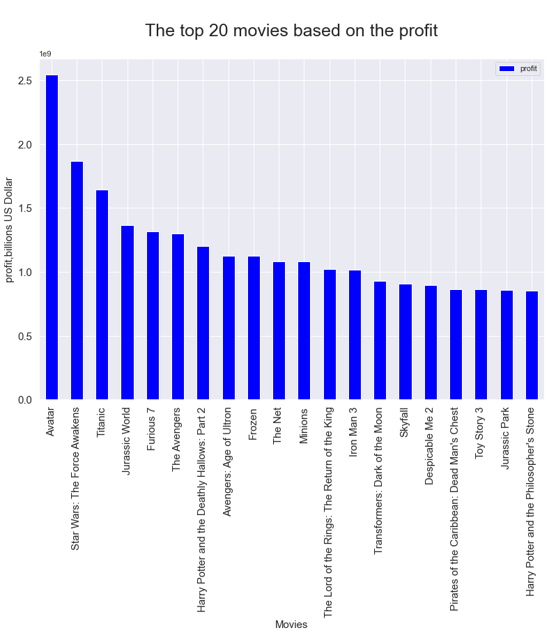

```python
#note we will remove Zero values from budget and revenue in this calculation
tmdb_b = tmdb[tmdb.budget != 0]
tmdb_zeros= tmdb_b[tmdb_b.revenue !=0]

# Calculate the Top 20 movies based on their net adjusted profit
movies_with_profit = tmdb_zeros[['original_title','profit']]

#sort columns
movies_with_profit = movies_with_profit.sort_values(by = 'profit',ascending = False).head(20)

#drow the data
movies_with_profit.plot(x = 'original_title', y = 'profit', kind = 'bar',color='blue',figsize = (13,9),fontsize=15);
plt.title(' \nThe top 20 movies based on the profit\n',fontsize = 25)
plt.xlabel("Movies", fontsize=15)
plt.ylabel("profit,billions US Dollar", fontsize=15)
plt.grid(True)
plt.savefig('top 20 movies on profit.jpg');
```

According to the shown Figure about the top 20 movies based on their net profit(revenue-budget) , The Top of those movies is still **Avatar** which was release on **2009**. produced by **Ingenious Film Partners|Twentieth Century Fox** and it's profit was more than **2,544,505,847** US Dollars . this movie was directed by **James Cameron**.

While the last movie in those top 20 of the highest profit is **Harry Potter and the Philosopher's Stone** , that was released on **2001** , produced by **1492 Pictures|Warner Bros.|Heyday Films** with net profit of **851,475,550** US Dollar ,that movie was directed by **Chris Columbus**.

### Research Question 4 (What are the Top 20 movies based on the user ratings?

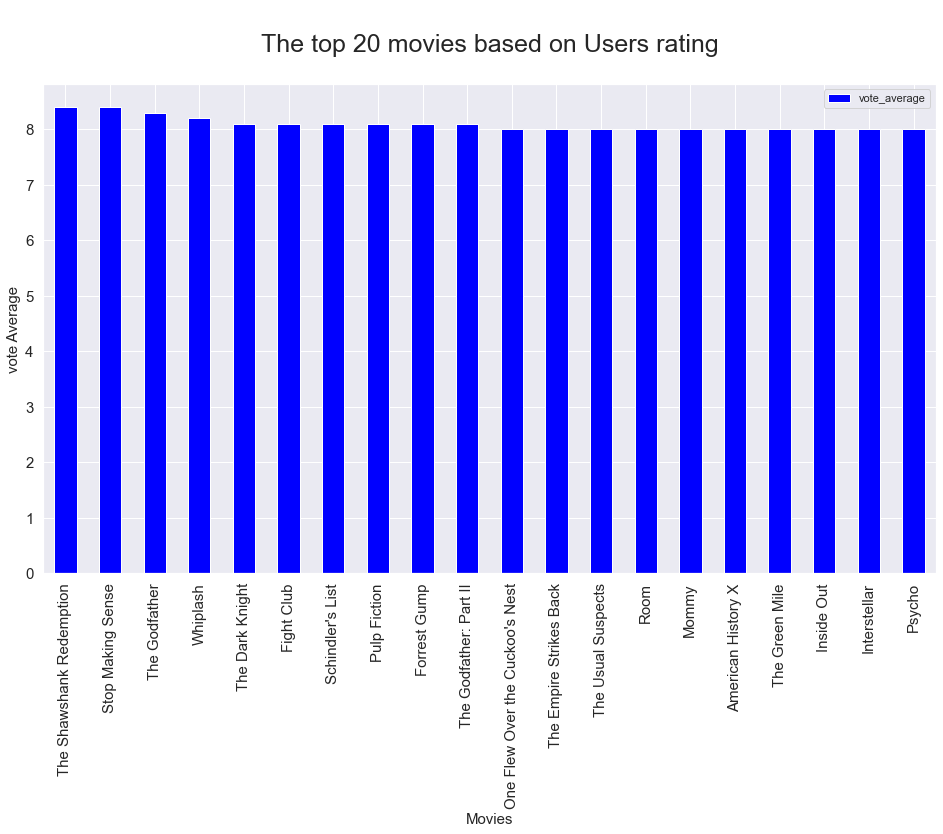

```python
#we will count the user ratings from colum ['vot_average']
movies_with_vote = tmdb[['original_title','vote_average']]

#sort columns
movies_with_vote = movies_with_vote.sort_values(by='vote_average',ascending=False).head(20)

#plot the data
movies_with_vote.plot(x = 'original_title', y = 'vote_average', kind = 'bar',color='blue',figsize = (16,9),fontsize=15);
plt.title(' \nThe top 20 movies based on Users rating\n',fontsize = 25)
plt.xlabel("Movies", fontsize=15)
plt.ylabel("vote Average", fontsize=15)

plt.grid(True)
plt.savefig('top 20 movies on rating.jpg');
```

analysis of Top 20 Movies based on the Valued of vote average , I believe it can be missleading for the true rating , since it mis count as apercentage from the tolta voters. so , If a movie have only 20 voters , but they all give to the movie 8 points , it will appeare as 8 for user rating.

so , we will check Top movies based on Popularity factor, as following.

### Research Question 5 (What are the Top 20 Movies based on the popularity?

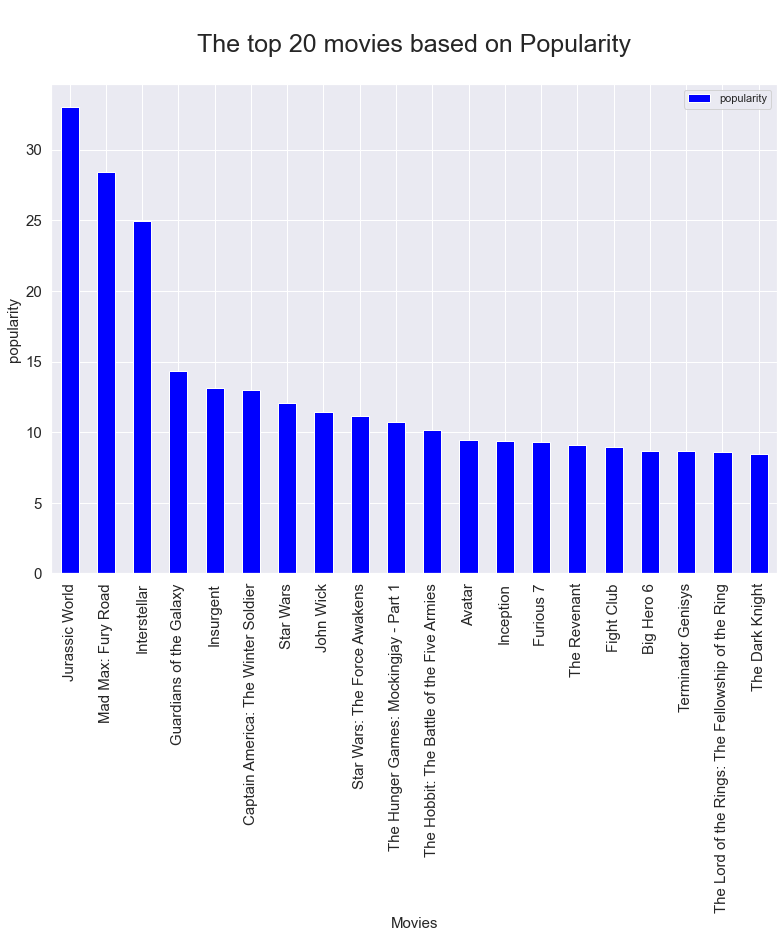

```python
#we will count the popularity from colum ['popularity']
movies_with_vote = tmdb[['original_title','popularity']]

#sort the data
movies_with_vote = movies_with_vote.sort_values(by='popularity',ascending=False).head(20)

#drow plot
movies_with_vote.plot(x = 'original_title', y = 'popularity', kind = 'bar',color='blue',figsize = (13,9),fontsize=15);
plt.title(' \nThe top 20 movies based on Popularity\n',fontsize = 25)
plt.xlabel("Movies", fontsize=15)
plt.ylabel("popularity", fontsize=15)

plt.grid(True)
plt.savefig('top 20 movies on popularity.jpg');
```

### Research Question 6 (what are the top 20 production copmanies?)

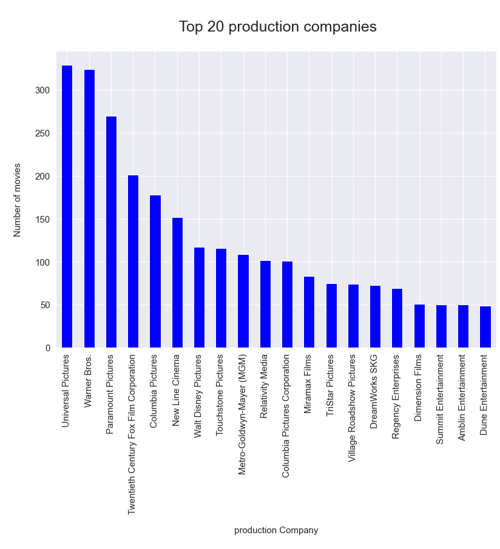

```python
#to count production for each company , We will use the count_genre function, from the previous question,as following

# I got this function from another Data analysis project about TMDB Dataset

#call the function for counting the movies of each genre.
def count(x):
#concatenate all the rows of the genrs.
    tmdb_plot = tmdb[x].str.cat(sep = '|')
    tmdb_split = pd.Series(tmdb_plot.split('|'))
#conts each of the genre and return.
    count = tmdb_split.value_counts(ascending=False)
    return count

production_companies = count('production_companies').head(20)

#check for the top 20 companies
production_companies_top=production_companies

#plot the data
production_companies_top.plot(kind= 'bar',color=['blue'],figsize = (13,9),fontsize=15)

#setup the title and the labels of the plot.
plt.title("\n Top 20 production companies\n",fontsize=25)
plt.ylabel('\nNumber of movies\n',fontsize=15)
plt.xlabel("\n production Company \n",fontsize= 15)
plt.grid(True)
plt.savefig('top 20 production companies.jpg');
```

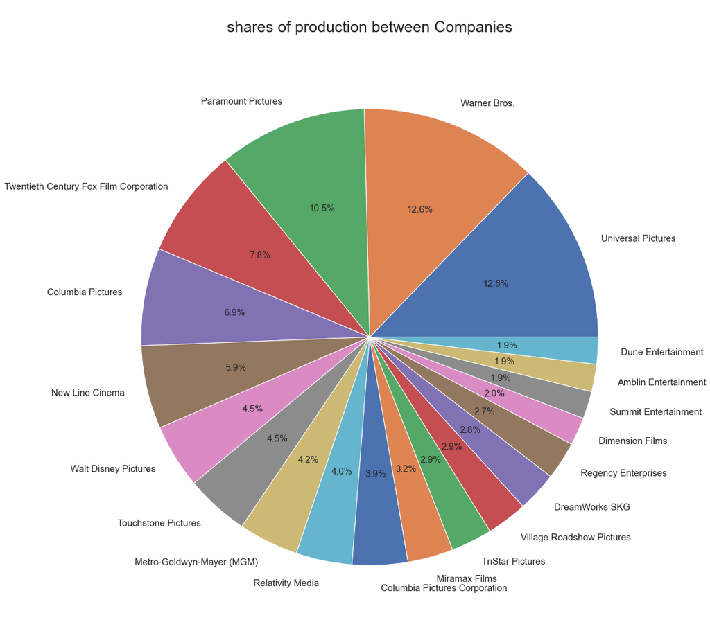

```python
production_companies = count('production_companies')
production_companies.sort_values(ascending=False)

production_companies_top.plot(kind= 'pie',autopct='%2.1f%%',figsize = (22,17),fontsize=15)
plt.title("\nshares of production between Companies\n",fontsize=25)
plt.xlabel("  ",fontsize=15)
plt.ylabel("  ",fontsize=15)
plt.grid(True)
plt.savefig('share of production between companies.jpg');
```

### Research Question 7 (which genres are most popular over year?

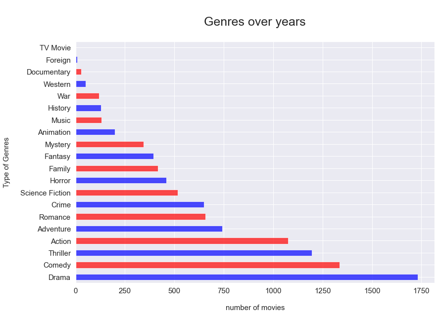

```python
#we will make a function to split the string and return the count of each genre.' it will also be used for other counts below'
#call the function for counting the movies of each genre.
total_genre= count('genres')

#plot the data
total_genre.plot(kind= 'barh',figsize = (13,9),fontsize=15,color=['blue','red'],alpha=0.7)

#setup the title and the labels of the plot.
plt.title("\nGenres over years\n",fontsize=25)
plt.xlabel('\nnumber of movies',fontsize=15)
plt.ylabel("Type of Genres\n",fontsize= 15)

plt.grid(True)
plt.savefig('genres over years.jpg');
```

a horisontal bar chart explain the number of movies in the dataset against the type of genres of those movies trhough that , we can easy see that the hot topic in all movies over years is **Drama** followed by **comody**.

this indicate who many times those topics were in the genres of movies , you have to notice that , for one movie it may be Drama and Comedy and even Rmoance in the same movie.

### Research Question 8 (How much was the production of movies over years?)

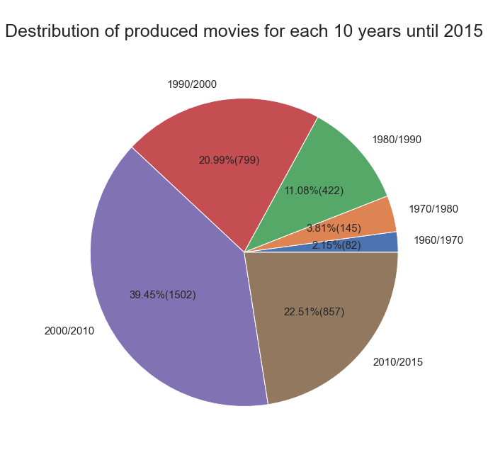

```python
#will describe years into groups ( 10 years for each group)
bin_edges =[1959,1970,1980,1990,2000,2010,2015]

#label for each group
bin_names = ['1960/1970','1970/1980','1980/1990','1990/2000','2000/2010','2010/2015']

#create years level column
tmdb['year_level'] = pd.cut(tmdb['release_year'], bin_edges, labels=bin_names)
tmdb.tail()

#call the function for counting the total of movies for each year.
title_count=tmdb.groupby('year_level')['original_title'].count()

#plot data
years=tmdb.groupby("year_level").size()
title_count = title_count.plot(kind = 'pie',figsize=(18,10),fontsize =15,autopct=lambda p: '{:.2f}%({:.0f})'.format(p,(p/100)*years.sum()))

title_count = title_count.plot(kind = 'pie',figsize=(22,17),fontsize =15)
plt.title('\nDestribution of produced movies for each 10 years until 2015\n', fontsize=25)
#plt.xlabel('\nRelease year\n',fontsize = 15)
plt.xlabel('',fontsize = 15)
plt.ylabel("")
plt.grid(True)
plt.savefig('Pie-produced movies over years.jpg');
```

fromthis Pie chart which shows us the production distribution for evet 10 years , we can see that , production is increasing gradualy each 10 years , but there was a great jump in movies production since 2001 , we cna refer that to many reasons , but one obvious one is the increase in technology usage in movies which make production more easy and fast and ofcourse , more exciting .

## Conclusions

First I have to say that , TMDB dataset is very very rich in information. you can get alot of analysis out of that data,however, their are some wrangling for the data must be done before any analysis , this is beacuse the dataset contains null and zero values in some features. also there was one record wsa duplicated . i norder to have good analysis all these zero and null values have to be removed.for example if we make correlation for any data contains zero values this will misslead. Therfore it is important to do data cleaning before the dataset's investigation.

those some of findings , I tried to figure them out , in my first project in Data Analysis,please , feel free to share any comments with me , to improve my Data analysis skills.